# Initial results

```r
load(here::here("data/2-stage.Rdata"))
```

## Hypotheses about how long a given transition will take:

### Major rules take longer at each stage than non-major rules.

Specifically, the time until half of major rules advance to each next stage will be longer than that for half of non-major rules:

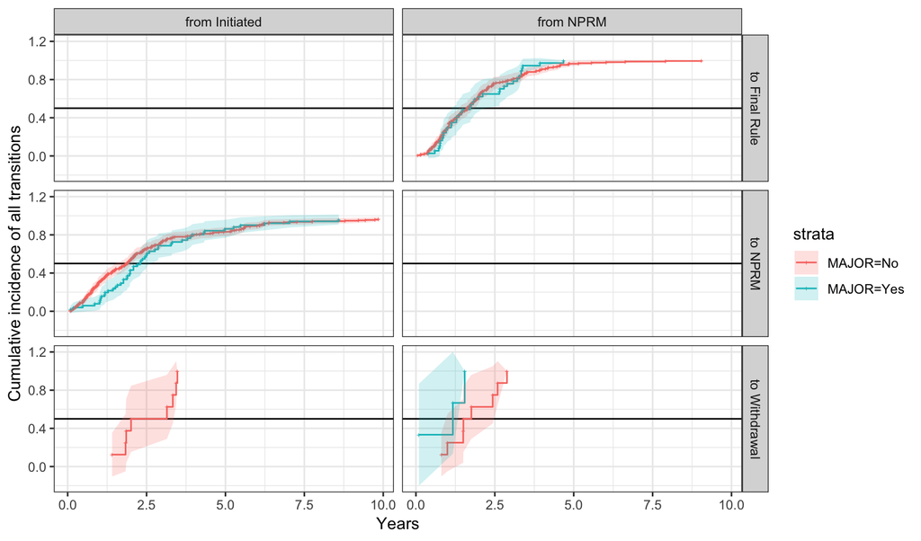

```r
fit <- survfit(Surv(time, status * as.numeric(transition), type = "mstate") ~ MAJOR + strata(transition),
               data = d) %>% tidy()
# FIXME
fit %<>%   filter(estimate != 0)

# replace numeric transition index with transition names (note: levels with too few observations may be dropped)
fit$state %<>% as.factor()
levels(fit$state) <- levels(d$transition)[as.numeric(levels(fit$state))]
fit$Transition <- fit$state

# make faceting variables for each current and future state
fit %<>%
  mutate(to = gsub(".*=|.* to ", "to ", Transition) ) %>%
  mutate(from = factor(paste("from", gsub(".*=| to .*","", Transition)) ) )
# trim srata
fit$strata %<>% str_replace(",.*", "")

# plot
fit %>% filter(time < 3650) %>%
  ggplot(aes(x = time/365, color = strata, fill = strata) ) +
  geom_hline(yintercept = .5) +
  geom_step(aes(y = estimate)) +
    geom_point(aes(y = estimate), shape = "+") +
  geom_ribbon(aes(ymax = estimate + 1.96*std.error,
                  ymin = estimate - 1.96*std.error),
              alpha = .2, color = NA) +
  # geom_text(aes(y = max, x = max(time/365), label = paste0(round(max*100), "%")), hjust = 1, vjust = -.2, color = "black") +
  labs(x = "Years" , y = "Cumulative incidence of all transitions") +
  #facet_grid(. ~ from) + # for comparing states without covariates
  facet_grid(to ~ from)# for comparing covariates within states
```

### Rulemaking is delayed by presidential transitions, but

### Withdrawal is accelerated by presidential transitions

Specifically:

1. The time until half of the rules initiated in a previous administration advance from initiated to NPRM or NPRM to Final will be *longer* than that for half of the rules began in the same administration to advance to the next stage in that same administration.
2. The time until half of the rules initiated in a previous administration but subsequently withdrawn will be *shorter* than that for half of the rules began and withdrawn in by the same administration:

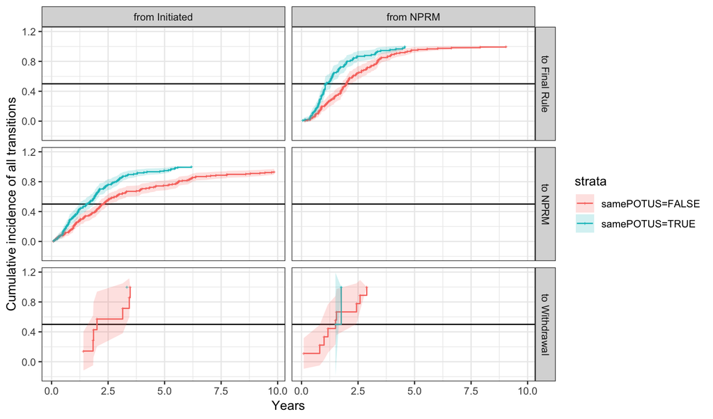

```r
library(lubridate)
obama <- list(interval(ymd("2009-01-01"), ymd("2017-01-01") ) )
d %<>% mutate(samePOTUS = ifelse(ymd(initiated) %within% obama & ymd(exit_date) %within% obama, T, F ) )

fit <- survfit(Surv(time, status * as.numeric(transition), type = "mstate") ~ samePOTUS + strata(transition),
               data = d) %>% tidy()
# FIXME
fit %<>%   filter(estimate != 0)

# replace numeric transition index with transition names (note: levels with too few observations may be dropped)
fit$state %<>% as.factor()
levels(fit$state) <- levels(d$transition)[as.numeric(levels(fit$state))]
fit$Transition <- fit$state

# make faceting variables for each current and future state
fit %<>%
  mutate(to = gsub(".*=|.* to ", "to ", Transition) ) %>%
  mutate(from = factor(paste("from", gsub(".*=| to .*","", Transition)) ) )
# trim srata
fit$strata %<>% str_replace(",.*", "")

# plot
fit %>% filter(time < 3650) %>%
  ggplot(aes(x = time/365, color = strata, fill = strata) ) +
  geom_hline(yintercept = .5) +
  geom_step(aes(y = estimate)) +
    geom_point(aes(y = estimate), shape = "+") +
  geom_ribbon(aes(ymax = estimate + 1.96*std.error,
                  ymin = estimate - 1.96*std.error),
              alpha = .2, color = NA) +
  # geom_text(aes(y = max, x = max(time/365), label = paste0(round(max*100), "%")), hjust = 1, vjust = -.2, color = "black") +
  labs(x = "Years" , y = "Cumulative incidence of all transitions") +
  #facet_grid(. ~ from) + # for comparing states without covariates
  facet_grid(to ~ from)# for comparing covariates within states
```

There is evidence that rulemaking is delayed, even in the pre-NPRM stage. However, we lack a sufficient number of withdrawals by the same administration to test whether withdrawals happen more quickly.

## Hypotheses about which transition will occur:

### Rulemaking projects are more likely to be withdrawn or otherwise terminated in both the pre-NPRM and post-NPRM stage after a new administration takes over.